# Instrukcja wykonania obliczeń LR w RStudio

Do rozdziału *Iloraz wiarygodności jako rekomendowane narzędzie weryfikacji hipotezy o wspólnym pochodzeniu dowodów rzeczowych

Zamieszczone przykłady pokazują krok po kroku, jak obliczyć LR. Praktyka chemometryczna nakazuje, aby najpierw model (1) skonstruować, (2) skontrolować jego efektywność, a następnie (3) zastosować go do porównania nieznanych próbek. Tutaj ta kolejność zostanie odwrócona, ponieważ obliczenia LR są dużo bardziej przejrzyste i łatwiejsze do pokazania krok po kroku zaczynając od etapu (3). Przykłady będą obejmowały następujące przypadki:

- obliczenia LR dla porównania dwóch próbek, jednej dowodowej i jednej porównawczej na podstawie jednej zmiennej (model jednowymiarowy) - folder I,
- obliczenia LR dla porównania dwóch próbek, jednej dowodowej i jednej porównawczej na podstawie kilku zmiennych (model wielowymiarowy) - folder I,
- obliczenia LR dla kilku par próbek dowodowych i porównawczych jednocześnie - folder I,
- obliczenia LR w celu oceny jakości modeli LR - folder II,
- obliczenia LR w hybrydowych modelach dla kilku par próbek dowodowych i porównawczych jednocześnie - folder III,
- obliczenia LR w celu oceny jakości hybrydowych modeli LR - folder IV.

Wszystkie przykłady obliczeń LR bazują na wzorach oraz opisach tworzenia i testowania modeli zamieszczonych w podrozdziałach *Konstrukcja modeli LR* oraz *Konstrukcja zbiorów uczących i testowych*.

Folder zamieszczony w repozytorium, zawierający wszystkie potrzebne funkcje oraz pliki z danymi, należy ściągnąć na urządzenie, na którym prowadzone będą obliczenia. W folderze tym znajdują się kolejne foldery I-IV zawierające opis każdego z ww. przykładów wraz z fragmentami kodu napisanymi w języku programowania R i odpowiednio skomentowanymi dla przejrzystości, a także kod gotowy do wykorzystania bez zbędnych komentarzy. Pliki wynikowe powstające w czasie egzekucji (wywołania/wykonania) kodu zapisane zostaną w tych samych odpowiednich folderach.

W celu efektywnego studiowania przykładów konieczne jest przeczytanie Instrukcji oraz zachowanie ich kolejności od I do IV. Stopień zaawansowania przykładów rośnie w kolejności ich pojawiania się, więc każdy przykład bazuje na wiedzy z poprzedniego.

## Jak używać RStudio?

Obliczenia LR można przeprowadzić wykorzystując skrypty napisane w języku programowania R. Skrypty te zawierają kod, którego celem jest uzyskanie wartości LR dla zadanych danych wejściowych. Egzekucję (wywołanie) kodu można przeprowadzić za pomocą tzw. IDE, czyli zintegrowanego środowiska programistycznego (ang. Integrated Development Environment), np. bezpłatnej wersji RStudio. By go wykorzystać należy zrealizować kilka kroków:

1. Ściągnij R oraz R Studio z odpowiednich stron internetowych (cran.r-project.org oraz www.rstudio.com).
2. Po zainstalowaniu obu aplikacji otwórz RStudio. Pojawi sie okno podzielone na kilka mniejszych części.
3. W menu głównym kliknij File->Open File i wybierz plik z rozszerzniem .R, w którym przechowywany jest kod do obliczeń, np. LR_comparison_casework_code.R. Jego zawartość pojawi się w lewym górnym oknie nazywanym Source. W oknie tym można dokonywać dowolnych modyfikacji kodu.
4. Przed egzekucją kodu należy ustalić tzw. working directory, czyli folder, z poziomu którego wykorzystujemy nasz kod. W naszym przypadku będzie to też folder, w którym zapisane zostaną pliki wynikowe. W tym celu w menu głównym kliknij Session->Set Working Directory->To Source File Location. Oznacza to, iż pracowwać będziemy w tym samym folderze, w którym znajduje się kod do obliczeń.
5. Kolejnym krokiem jest wywołanie (egzekucja) kodu poprzez kliknięcie na ikonkę Source w prawym górnym rogu okienka Source. Po kilku chwilach ikonka przypominająca znak STOP w Konsoli poniżej zniknie, co oznacza, iż obliczenia zostały zakończone. Wyniki można zobaczyć w postaci zapisanych w folderze plików wynikowych, ale także wpisując nazwy poszukiwanych zmiennych w Konsoli. Generowane przez kod grafiki pojawiają się w zakładce Plots po prawej stronie.

Szczegółowe informacje o pracy i użytecznych funkcjonalnościach RStudio można znaleźć na stronie internetowej np. support.rstudio.com.

Pojedyncze linijki kodu można wywyływać zarówno w Konsoli porzez ich wpisanie (lub wklejenie z innego źródła) i kliknięcie Enter lub poprzez wpisanie (lub wklejenie z innego źródła) w oknie Source i kliknięcie na ikonkę Source. Wywołanie zaznaczonych poprzez podświetlenie linijek lub linijki, w której aktualnie znajduje sie kursor następuje po kliknięciu na ikonkę Run.

Poniższa grafika pokazuje pewne funkcjonalności RStudio, na które należy zwrócić uwagę, by wywołać prawidłowo kod.

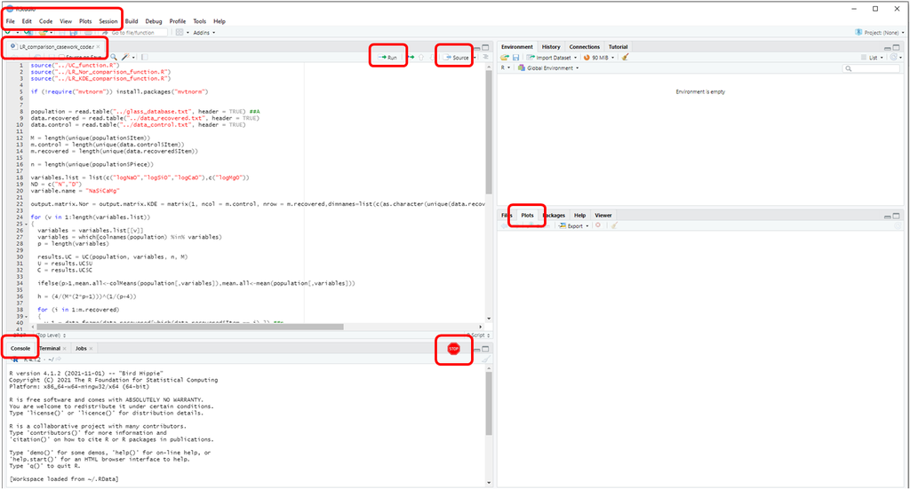